# The State of Data Journalism in Portugal, Italy, Greece and Spain

What makes data journalism in PIGS different from the rest of Europe?

Author: Rui Barros e José Volta e Pinto

Date: February 4, 2025

# Introduction

This document intends to provide a focused analysis of the state of Data Journalism in Portugal, Italy, Greece and Spain. The analysis is based on the [State of Data Journalism 2023 survey](https://ejc.net/state-of-data-journalism-survey-2023) conducted by the European Journalism Centre (EJC).

Although the EJC had conducted the survey since 2021, we opted to only include the data for 2023 since it’s the most recent year available. The survey was open between December 7th, 2023 and January 16th, 2024. Participation was encouraged through direct mailing, social media promotion, and asking the DataJournalism.com and European Journalism Centre network of contacts for help in spreading the word. Targeted respondents include full and part time employed data journalists, as well as freelancers; data editors and team leads; trainers, faculty members and educators; students.

Because it’s a survey, it’s hard to tell how representative the results are of the population it represents. But since there isn’t a unified body that states if someone can be considered a data journalist or not, or either a clear dataset of how many data journalists are per country, we believe that the survey is a good proxy to get a sense of the state of data journalism in each country.

The analysis was conducted by PÚBLICO’s data jounalism team and the conclusions can only be attributed to them and them alone. European Journalism Centre (EJC) only provided the raw data and did not conduct this analysis.

# Analysis

```r
library(tidyverse)
library(janitor)
library(readxl)
library(DT)
library(ggbeeswarm)
```

## Data cleaning

```r
df <- read_excel("stateofdatajournalism2023_open_anonymised_dataset.xlsx")
pigs <- c("Portugal", "Spain", "Italy", "Greece")
rest_eu <- c("Austria", "Belgium", "Bulgaria", "Croatia", "Cyprus", "Czech Republic", "Denmark", "Estonia", "Finland", "France", "Germany", "Hungary", "Ireland", "Latvia", "Lithuania", "Luxembourg", "Malta", "Netherlands", "Poland", "Romania", "Slovakia", "Slovenia", "Sweden", "France")

nrow(df)
```

```
[1] 768
```

```r
df <- df %>%
  filter(work_study_loc %in% c(pigs, rest_eu))

nrow(df)
```

```
[1] 290
```

```r
df %>%
  count(occupation) |>
  arrange(desc(n)) |>
  datatable()
```

|  | occupation | n |
| --- | --- | --- |
| 1 | Full-time employment at a news company/organisation | 92 |
| 2 | Full-time freelancer | 44 |
| 3 | Part-time freelancer | 30 |
| 4 | Student | 29 |
| 5 | Editor/ Team lead | 22 |
| 6 | Other (Please specify) | 18 |
| 7 | Part-time employment at a news company/organisation | 18 |
| 8 | None of the above | 17 |
| 9 | Teacher / Educator / Trainer / Faculty member | 16 |
| 10 | I am a retired data journalist | 4 |

Because the survey wanted to focus on practicing professionals, we decided to only include the respondents that identified themselves as: - Full-time employment at a news company/organisation; - Full-time freelancer; - Part-time freelancer; - Editor/ Team lead; - Part-time employment at a news company/organisation;

```r
df %>%
  filter(occupation == "Other (Please specify)") %>%
  select(occupation, occupation_other) %>%
  datatable()
```

|  | occupation | occupation_other |
| --- | --- | --- |
| 1 | Other (Please specify) | An aspiring data journalist |
| 2 | Other (Please specify) | Full time employment at media organisation |
| 3 | Other (Please specify) | Full time - radio journalist |
| 4 | Other (Please specify) | I'm full-time employed at a news company, but we don't do a lot of data journalism. |
| 5 | Other (Please specify) | I work in data visualization space and clients I interacted with were in data journalism |
| 6 | Other (Please specify) | I am a full time journalist at a news org but I use data journalism skills sporadically |
| 7 | Other (Please specify) | I am a freelancer and from time to time I use data journalism |
| 8 | Other (Please specify) | I use data from time to time in my job as editor |
| 9 | Other (Please specify) | Research &amp; Innovation Proposal Writer at an IT environmentla organization |
| 10 | Other (Please specify) | Development and communications officer at NGO |

[output cut: 8 more lines]

Since one of the options was “Other (Please specify)”, we decided to analyse furher so that we could include every single person that we believe qualifies as a data journalist. Some respondents in this category sounded like they were afraid of considering themselves as data journalists, stating things like “I am a full time journalist at a news org but I use data journalism skills sporadically”. We decided to include them, but we excluded all answers that worked in Public Relations, Marketing, or Communications.

```r
occupations_include <- c("Full-time employment at a news company/organisation","Full-time freelancer","Part-time freelancer","Editor/ Team lead","Part-time employment at a news company/organisation","Other (Please specify)")

occupations_other <- c("Full time - radio journalist","Full time employment at media organisation","I'm full-time employed at a news company, but we don't do a lot of data journalism.","I am a full time journalist at a news org but I use data journalism skills sporadically","I am a freelancer and from time to time I use data journalism","I use data from time to time in my job as editor","Trabajo como periodista sanitaria y ocasionalmente hago periodismo de datos sobre salud","Corresponsal que recurre a veces al periodismo de datos","Freelance e studente", NA)

df <- df %>%
  filter(occupation %in% occupations_include) |>
  filter(occupation_other %in% occupations_other)
```

```r
df <- df %>%
  mutate(pigs = ifelse(work_study_loc %in% pigs, TRUE, FALSE))

df |>
  group_by(pigs) |>
  count() |>
  mutate(per = (n/nrow(df))*100) |>
  datatable()
```

|  | pigs | n | per |
| --- | --- | --- | --- |
| 1 | False | 142 | 66.04651162790698 |
| 2 | True | 73 | 33.95348837209302 |

```r
write_csv(df, "data_pigs.csv")
```

With all these filter applied, we have 215 respondents that we deem to be data journalists in an European country for the purposes of this analysis. Of those, we have 73 (about 33.95%) that are from Portugal, Italy, Greece and Spain.

## Global analysis

```r
per_country <- df |>
  group_by(work_study_loc) |>
  count() |>
  mutate(per = (n/nrow(df))*100) |>
  arrange(-per)

per_country  |>
  datatable()
```

|  | work_study_loc | n | per |
| --- | --- | --- | --- |
| 1 | Germany | 38 | 17.67441860465116 |
| 2 | Italy | 34 | 15.81395348837209 |
| 3 | Spain | 21 | 9.767441860465116 |
| 4 | France | 18 | 8.372093023255815 |
| 5 | Romania | 15 | 6.976744186046512 |
| 6 | Portugal | 12 | 5.581395348837209 |
| 7 | Netherlands | 9 | 4.186046511627907 |
| 8 | Czech Republic | 8 | 3.720930232558139 |
| 9 | Belgium | 7 | 3.255813953488372 |
| 10 | Sweden | 7 | 3.255813953488372 |

[output cut: 15 more lines]

Regarding the number of respondents, Germany is the most represented country (38 journalists), followed by Italy (34), Spain (21) and France(18). Portugal also has 12 respondents and Greece has 6.

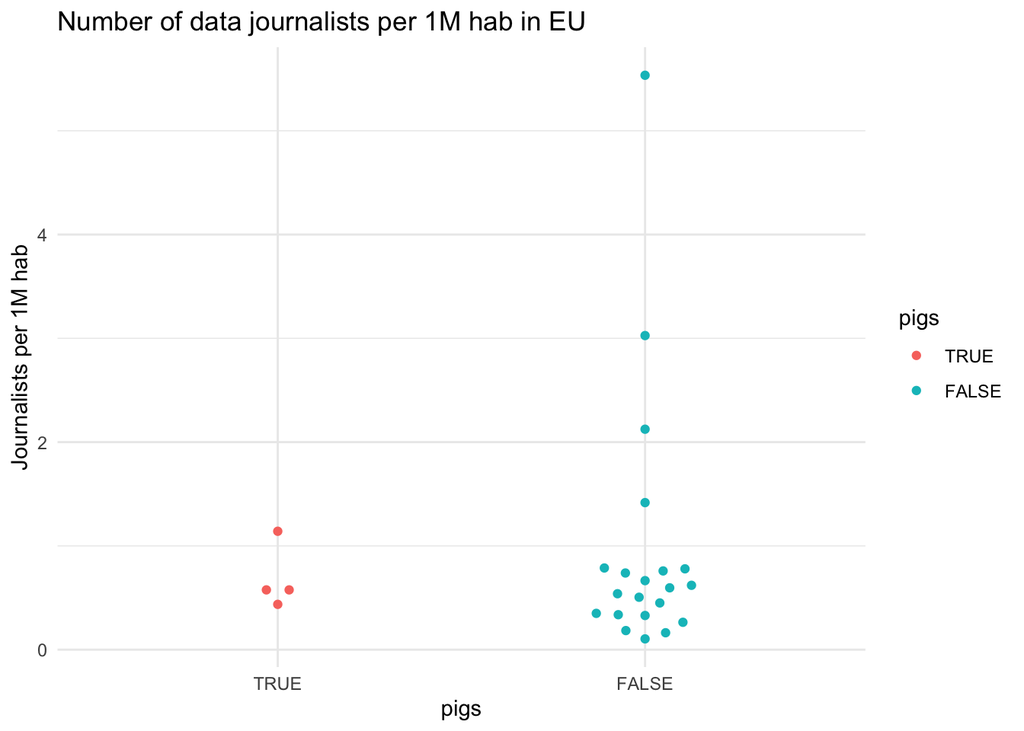

```r
pop <- read_delim("population_eu.csv", delim = ";")
per_country <- df |>
  group_by(work_study_loc) |>
  count() |>
  mutate(per = (n/nrow(df))*100) |>
  arrange(-per)

per_country <- per_country |>
  left_join(pop, by = c("work_study_loc" = "Country")) |>
  mutate(per = (n/pop)*1000000)

m <- per_country  |>
  mutate(pigs = ifelse(work_study_loc %in% pigs, TRUE, FALSE))

m <- m |>
  mutate(pigs = factor(pigs, levels = c(TRUE, FALSE)))

ggplot(m, aes(y = per, x = pigs, colour = pigs, fill = pigs)) +
    geom_beeswarm(cex = 3) +
    theme_minimal() +
    labs(title="Number of data journalists per 1M hab in EU",
          y="Journalists per 1M hab")
```

The absolute numbers can give the impression that PIGS countries have a good number of data journalists (specially compared to other places in Europe). Even when we look at the data per 1M habitants, PIGS countries are not that different from the rest of Europe.

The number of respondents can be although, misleading, since we don’t know if the survey didn’t got higher response rates in some countries, if the media sector has more workers in each case, etc.

# Main findings

To understand how different PIGS and non-PIGS countries are data journalism wise, we compared the Chi-square test between the two groups. This statistical test is used to determine if there is a significant difference between two groups. The null hypothesis is that there is no difference between the two groups, while the alternative hypothesis is that there is a difference.

Because the Chi-square (χ^2) can show a relationship only by chance, for every relatiosnhip we also calculated the p-value. This can allow us to determine if the relationship verified happens by chance or if it is real. Only values with a p-value lower than 0.05 or closer to it were considered for this analysis.

The current analysis focuses mostly only on the tests where there was a significant difference between the two groups. Other tests were explored but, for the sake of simplicity, we only included the ones that were significant.

## PIGS journalists engage in significantly fewer cross-border investigative projects than their EU counterparts

```r
test_table <- table(df$pigs, df$collaboration)
chisq.test(test_table)
```

```
    Pearson's Chi-squared test with Yates' continuity correction

data:  test_table
X-squared = 7.5374, df = 1, p-value = 0.006043
```

The data available reveals that only 10 journalists in Portugal, Italy, Greece and Spain collaborate with other journalists from other countries during 2023. The fact that 14% of the respondents in PIGS countries collaborated with other news companies/organisations on a data journalism projects contrasts with the fact that, in the rest of Europe, this value is 32%.

There is a statistically significant difference in the level of collaboration between journalists in PIGS countries and their EU counterparts. With the data suggesting that PIGS journalists engage in significantly fewer cross-border investigative projects compared to other EU journalists.

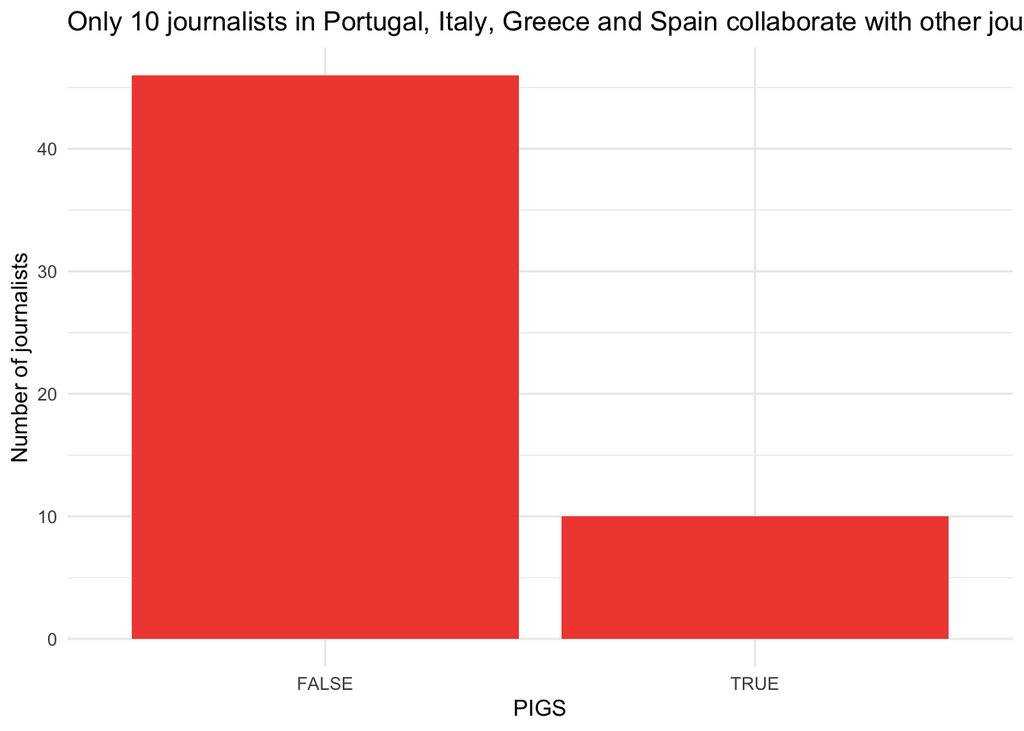

```r
df |>
  group_by(pigs, collaboration) |>
  summarise(n = n()) |>
  filter(collaboration == "Yes") |>
  ggplot(aes(x = pigs, y = n)) +
    geom_bar(stat = "identity", fill = "#F14D3E") +
    theme_minimal() +
    labs(title = "Only 10 journalists in Portugal, Italy, Greece and Spain collaborate with other journalists from other countries during 2023",
         x = "PIGS",
         y = "Number of journalists")
```

## PIGS journalists report significantly worse access to national and local data compared to other EU journalists

Since “access_local” and “access_national” variables use a categorical scale (Very Poor, Poor, Average, Good, and Very Good), we converted them to a numeric scale using the following logic:

```r
ordinal_mapping <- c("Very Poor" = 1, "Poor" = 2, "Average" = 3, "Good" = 4, "Very Good" = 5)
ordinal_mapping
```

```
Very Poor      Poor   Average      Good Very Good
        1         2         3         4         5
```

Because we are using categorical data, we decided to use the Mann-Whitney U test to compare the distributions of the two variables. This test is used to determine if there is a significant difference between two groups. The null hypothesis is that there is no difference between the two groups, while the alternative hypothesis is that there is a difference.

```r
df$access_local_numeric <- as.numeric(factor(df$access_local, levels = names(ordinal_mapping), labels = ordinal_mapping))
df$access_national_numeric <- as.numeric(factor(df$access_national, levels = names(ordinal_mapping), labels = ordinal_mapping))

# Separate PIGS and non-PIGS groups
pigs_local <- df$access_local_numeric[df$pigs == TRUE]
non_pigs_local <- df$access_local_numeric[df$pigs == FALSE]

pigs_national <- df$access_national_numeric[df$pigs == TRUE]
non_pigs_national <- df$access_national_numeric[df$pigs == FALSE]

# Perform Mann-Whitney U test
local_mwu <- wilcox.test(pigs_local, non_pigs_local, alternative = "less")
national_mwu <- wilcox.test(pigs_national, non_pigs_national, alternative = "less")

# Print results
print(local_mwu)
```

```
    Wilcoxon rank sum test with continuity correction

data:  pigs_local and non_pigs_local
W = 3627, p-value = 0.0002289
alternative hypothesis: true location shift is less than 0
```

```r
print(national_mwu)
```

```
    Wilcoxon rank sum test with continuity correction

data:  pigs_national and non_pigs_national
W = 3926.5, p-value = 0.00322
alternative hypothesis: true location shift is less than 0
```

Both Mann-Whitney U tests showed a significant difference in the distribution of the two variables.

The results show a clear pattern: journalists in PIGS countries report significantly worse access to both local and national data than their EU counterparts. This means that, compared to journalists in other parts of Europe, they are more likely to struggle when trying to obtain official information.

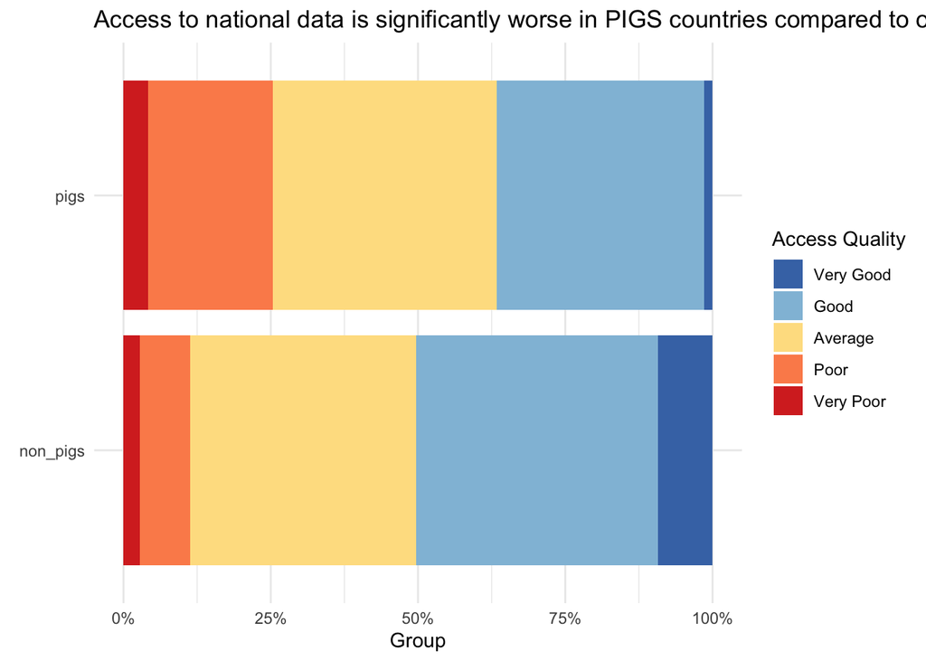

```r
per_quality_acess_national <- df |>
  group_by(pigs, access_national) |>
  count() |>
  pivot_wider(
    names_from = pigs,
    values_from = n
  ) |>
  rename(non_pigs = `FALSE`, pigs = `TRUE`) |>
  filter(!is.na(access_national))

#transform to factor
per_quality_acess_national$access_national <- factor(per_quality_acess_national$access_national,
  levels = rev(names(ordinal_mapping)),
  labels = rev(c("Very Poor", "Poor", "Average", "Good", "Very Good")))

per_quality_acess_national <- per_quality_acess_national |>
  pivot_longer(cols = c(non_pigs, pigs), names_to = "pigs", values_to = "n")

# Column chart with ordered fill
ggplot(per_quality_acess_national, aes(y = pigs, fill = access_national, x = n)) +
  geom_col(position = "fill") +
  scale_fill_manual(values = rev(c("#d73027", "#fc8d59", "#fee090", "#91bfdb", "#4575b4"))) +
  labs(x = "Group" , y = element_blank(), fill = "Access Quality", title = "Access to national data is significantly worse in PIGS countries compared to other EU countries") +
  scale_x_continuous(labels = scales::percent) +  #
  theme_minimal()
```

This document was made using Quarto and the [Lumo](https://www.productive-r-workflow.com/r/bonus/lumo-quarto-template) format.